# Portfolio 3

Cassandra Richardson

5/4/2022

# **Cassandra Richardson’s Portfolio Piece #3 - Data Analysis Report on Common Drug Use by Age**

# Step 1: Finding a dataset.

### The dataset I will be using for this project is “drug-use-by-age” from the FiveThirtyEight datasets. This data was sourced by the National Survey on Drug Use and Health from the Substance Abuse and Mental Health Data Archive. The data can be found here: https://github.com/fivethirtyeight/data/tree/master/drug-use-by-age

### Dataset description: This dataset covers usage of 13 different drugs across 17 age groups. For each drug, there is information about the “use,” which is the percentage of those in an age group that have used that drug in the last 12 months, and “frequency,” which is the median number of times a user in that age group used that drug in the past 12 months.

# Step 2: Develop a research plan.

### For this data analysis report, I want to examine the usage of three drugs: alcohol, marijuana, and hallucinogens. My rationale for choosing these drugs is that I expect the perceptions of each drug to vary across age. Alcohol is the most common drug in the US, and views on marijuana and hallucinogens have been changing in recent years as their therapeutic benefits are being recognized, with laws reflecting this through their legalization or decriminalization.

### With these three variables, I want to examine trends in both use and frequency across age groups.

### Hypotheses:

1. Alcohol use will not significantly differ with age, but frequency will significantly differ by age.
2. Marijuana use will be significantly different by age, but frequency will not significantly differ by age.
3. Hallucinogen use will be significantly different by age, but frequency will not signficantly differ by age.

# Step 3: Before we begin any analyses, let’s examine what this dataset includes:

```r
#View(drugs)
summary(drugs)
```

```
##      age                  n         alcohol.use    alcohol.frequency
##  Length:17          Min.   :2223   Min.   : 3.90   Min.   : 3.00
##  Class :character   1st Qu.:2469   1st Qu.:40.10   1st Qu.:10.00
##  Mode  :character   Median :2798   Median :64.60   Median :48.00
##                     Mean   :3251   Mean   :55.43   Mean   :33.35
##                     3rd Qu.:3058   3rd Qu.:77.50   3rd Qu.:52.00
##                     Max.   :7391   Max.   :84.20   Max.   :52.00
##  marijuana.use   marijuana.frequency  cocaine.use    cocaine.frequency
##  Min.   : 1.10   Min.   : 4.00       Min.   :0.000   Length:17
##  1st Qu.: 8.70   1st Qu.:30.00       1st Qu.:0.500   Class :character
##  Median :20.80   Median :52.00       Median :2.000   Mode  :character
##  Mean   :18.92   Mean   :42.94       Mean   :2.176
##  3rd Qu.:28.40   3rd Qu.:52.00       3rd Qu.:4.000
##  Max.   :34.00   Max.   :72.00       Max.   :4.900
##    crack.use      crack.frequency      heroin.use     heroin.frequency
##  Min.   :0.0000   Length:17          Min.   :0.0000   Length:17
##  1st Qu.:0.0000   Class :character   1st Qu.:0.1000   Class :character
##  Median :0.4000   Mode  :character   Median :0.2000   Mode  :character
##  Mean   :0.2941                      Mean   :0.3529
##  3rd Qu.:0.5000                      3rd Qu.:0.6000
##  Max.   :0.6000                      Max.   :1.1000
##  hallucinogen.use hallucinogen.frequency  inhalant.use   inhalant.frequency
##  Min.   :0.100    Min.   : 2.000         Min.   :0.000   Length:17
##  1st Qu.:0.600    1st Qu.: 3.000         1st Qu.:0.600   Class :character
##  Median :3.200    Median : 3.000         Median :1.400   Mode  :character
##  Mean   :3.394    Mean   : 8.412         Mean   :1.388
##  3rd Qu.:5.200    3rd Qu.: 4.000         3rd Qu.:2.000
##  Max.   :8.600    Max.   :52.000         Max.   :3.000
##  pain.releiver.use pain.releiver.frequency oxycontin.use    oxycontin.frequency
##  Min.   : 0.600    Min.   : 7.00           Min.   :0.0000   Length:17
##  1st Qu.: 3.900    1st Qu.:12.00           1st Qu.:0.4000   Class :character
##  Median : 6.200    Median :12.00           Median :1.1000   Mode  :character
##  Mean   : 6.271    Mean   :14.71           Mean   :0.9353
##  3rd Qu.: 9.000    3rd Qu.:15.00           3rd Qu.:1.4000
##  Max.   :10.000    Max.   :36.00           Max.   :1.7000
##  tranquilizer.use tranquilizer.frequency stimulant.use   stimulant.frequency
##  Min.   :0.200    Min.   : 4.50          Min.   :0.000   Min.   :  2.00
##  1st Qu.:1.400    1st Qu.: 6.00          1st Qu.:0.600   1st Qu.:  7.00
##  Median :3.500    Median :10.00          Median :1.800   Median : 10.00
##  Mean   :2.806    Mean   :11.74          Mean   :1.918   Mean   : 31.15
##  3rd Qu.:4.200    3rd Qu.:11.00          3rd Qu.:3.000   3rd Qu.: 12.00
##  Max.   :5.400    Max.   :52.00          Max.   :4.100   Max.   :364.00
##     meth.use      meth.frequency      sedative.use    sedative.frequency
##  Min.   :0.0000   Length:17          Min.   :0.0000   Min.   :  3.00
##  1st Qu.:0.2000   Class :character   1st Qu.:0.2000   1st Qu.:  6.50
##  Median :0.4000   Mode  :character   Median :0.3000   Median : 10.00
##  Mean   :0.3824                      Mean   :0.2824   Mean   : 19.38
##  3rd Qu.:0.6000                      3rd Qu.:0.4000   3rd Qu.: 17.50
##  Max.   :0.9000                      Max.   :0.5000   Max.   :104.00
```

### The “view()” function opens the full dataset file in a new tab, so we can visually examine what the data looks like.

### The “summary()” function gives us the min, max, 1st quartile, mean, and 3rd quartile for all quantitative variables. However, it looks like some of our variables are character variables when they should be numeric - we will need to change this in our data cleaning.

# Step 4: Let’s explore some more characteristics about the data:

```r
glimpse(drugs)
```

```
## Rows: 17
## Columns: 28
## $ age                     <chr> "12", "13", "14", "15", "16", "17", "18", "19"~
## $ n                       <int> 2798, 2757, 2792, 2956, 3058, 3038, 2469, 2223~
## $ alcohol.use             <dbl> 3.9, 8.5, 18.1, 29.2, 40.1, 49.3, 58.7, 64.6, ~
## $ alcohol.frequency       <dbl> 3, 6, 5, 6, 10, 13, 24, 36, 48, 52, 52, 52, 52~
## $ marijuana.use           <dbl> 1.1, 3.4, 8.7, 14.5, 22.5, 28.0, 33.7, 33.4, 3~
## $ marijuana.frequency     <dbl> 4, 15, 24, 25, 30, 36, 52, 60, 60, 52, 52, 60,~
## $ cocaine.use             <dbl> 0.1, 0.1, 0.1, 0.5, 1.0, 2.0, 3.2, 4.1, 4.9, 4~
## $ cocaine.frequency       <chr> "5.0", "1.0", "5.5", "4.0", "7.0", "5.0", "5.0~
## $ crack.use               <dbl> 0.0, 0.0, 0.0, 0.1, 0.0, 0.1, 0.4, 0.5, 0.6, 0~
## $ crack.frequency         <chr> "-", "3.0", "-", "9.5", "1.0", "21.0", "10.0",~
## $ heroin.use              <dbl> 0.1, 0.0, 0.1, 0.2, 0.1, 0.1, 0.4, 0.5, 0.9, 0~
## $ heroin.frequency        <chr> "35.5", "-", "2.0", "1.0", "66.5", "64.0", "46~
## $ hallucinogen.use        <dbl> 0.2, 0.6, 1.6, 2.1, 3.4, 4.8, 7.0, 8.6, 7.4, 6~
## $ hallucinogen.frequency  <dbl> 52, 6, 3, 4, 3, 3, 4, 3, 2, 4, 3, 2, 3, 2, 3, ~
## $ inhalant.use            <dbl> 1.6, 2.5, 2.6, 2.5, 3.0, 2.0, 1.8, 1.4, 1.5, 1~
## $ inhalant.frequency      <chr> "19.0", "12.0", "5.0", "5.5", "3.0", "4.0", "4~
## $ pain.releiver.use       <dbl> 2.0, 2.4, 3.9, 5.5, 6.2, 8.5, 9.2, 9.4, 10.0, ~
## $ pain.releiver.frequency <dbl> 36, 14, 12, 10, 7, 9, 12, 12, 10, 15, 15, 15, ~
## $ oxycontin.use           <dbl> 0.1, 0.1, 0.4, 0.8, 1.1, 1.4, 1.7, 1.5, 1.7, 1~
## $ oxycontin.frequency     <chr> "24.5", "41.0", "4.5", "3.0", "4.0", "6.0", "7~
## $ tranquilizer.use        <dbl> 0.2, 0.3, 0.9, 2.0, 2.4, 3.5, 4.9, 4.2, 5.4, 3~
## $ tranquilizer.frequency  <dbl> 52.0, 25.5, 5.0, 4.5, 11.0, 7.0, 12.0, 4.5, 10~
## $ stimulant.use           <dbl> 0.2, 0.3, 0.8, 1.5, 1.8, 2.8, 3.0, 3.3, 4.0, 4~
## $ stimulant.frequency     <dbl> 2.0, 4.0, 12.0, 6.0, 9.5, 9.0, 8.0, 6.0, 12.0,~
## $ meth.use                <dbl> 0.0, 0.1, 0.1, 0.3, 0.3, 0.6, 0.5, 0.4, 0.9, 0~
## $ meth.frequency          <chr> "-", "5.0", "24.0", "10.5", "36.0", "48.0", "1~
## $ sedative.use            <dbl> 0.2, 0.1, 0.2, 0.4, 0.2, 0.5, 0.4, 0.3, 0.5, 0~
## $ sedative.frequency      <dbl> 13.0, 19.0, 16.5, 30.0, 3.0, 6.5, 10.0, 6.0, 4~
```

```r
head(drugs)
```

```
##   age    n alcohol.use alcohol.frequency marijuana.use marijuana.frequency
## 1  12 2798         3.9                 3           1.1                   4
## 2  13 2757         8.5                 6           3.4                  15
## 3  14 2792        18.1                 5           8.7                  24
## 4  15 2956        29.2                 6          14.5                  25
## 5  16 3058        40.1                10          22.5                  30
## 6  17 3038        49.3                13          28.0                  36
##   cocaine.use cocaine.frequency crack.use crack.frequency heroin.use
## 1         0.1               5.0       0.0               -        0.1
## 2         0.1               1.0       0.0             3.0        0.0
## 3         0.1               5.5       0.0               -        0.1
## 4         0.5               4.0       0.1             9.5        0.2
## 5         1.0               7.0       0.0             1.0        0.1
## 6         2.0               5.0       0.1            21.0        0.1
##   heroin.frequency hallucinogen.use hallucinogen.frequency inhalant.use
```

[output cut: 27 more lines]

```r
names(drugs)
```

```
##  [1] "age"                     "n"
##  [3] "alcohol.use"             "alcohol.frequency"
##  [5] "marijuana.use"           "marijuana.frequency"
##  [7] "cocaine.use"             "cocaine.frequency"
##  [9] "crack.use"               "crack.frequency"
## [11] "heroin.use"              "heroin.frequency"
## [13] "hallucinogen.use"        "hallucinogen.frequency"
## [15] "inhalant.use"            "inhalant.frequency"
## [17] "pain.releiver.use"       "pain.releiver.frequency"
## [19] "oxycontin.use"           "oxycontin.frequency"
## [21] "tranquilizer.use"        "tranquilizer.frequency"
## [23] "stimulant.use"           "stimulant.frequency"
## [25] "meth.use"                "meth.frequency"
## [27] "sedative.use"            "sedative.frequency"
```

```r
missing <- !complete.cases(drugs)
drugs[missing]
```

```
## data frame with 0 columns and 17 rows
```

### - glimpse() shows us an overview of the whole dataset. We see that there are 17 rows and 28 columns.

### - head() gives us the first 6 rows of data

### - names() tells us all of the variable names

### - missing <- !complete.cases() creates an object/tibble called “missing” with any missing observations across the entire dataset

### - drugs[missing] shows us that the “missing” tibble has 0 columns. This means that there was no missing data in this dataset, which makes it easier to work with! However, when I looked at the data through the “View()” function, I noticed there is at least one breed with values of “-” which will need to be removed during data cleaning.

# Step 5: Before we begin our analyses, let’s **clean the data**!

### First, I want to remove the values of “not found”:

```r
drugs_clean <- na_if(drugs, "-")
#View(drugs_clean)
```

### Perfect! Looking at the new datset, we see that all values of “-” were replaced with NA.

### Although we won’t be using all drugs in our analyses, let’s still fix them for the sake of cleaning the data and making it easier for future analyses. As such, let’s change the character variables to numeric variables:

```r
sapply(drugs_clean, class)
```

```
##                     age                       n             alcohol.use
##             "character"               "integer"               "numeric"
##       alcohol.frequency           marijuana.use     marijuana.frequency
##               "numeric"               "numeric"               "numeric"
##             cocaine.use       cocaine.frequency               crack.use
##               "numeric"             "character"               "numeric"
##         crack.frequency              heroin.use        heroin.frequency
##             "character"               "numeric"             "character"
##        hallucinogen.use  hallucinogen.frequency            inhalant.use
##               "numeric"               "numeric"               "numeric"
##      inhalant.frequency       pain.releiver.use pain.releiver.frequency
##             "character"               "numeric"               "numeric"
##           oxycontin.use     oxycontin.frequency        tranquilizer.use
##               "numeric"             "character"               "numeric"
##  tranquilizer.frequency           stimulant.use     stimulant.frequency
##               "numeric"               "numeric"               "numeric"
##                meth.use          meth.frequency            sedative.use
##               "numeric"             "character"               "numeric"
##      sedative.frequency
##               "numeric"
```

```r
drugs_clean$cocaine.frequency <- as.numeric(drugs_clean$cocaine.frequency)
drugs_clean$crack.frequency <- as.numeric(drugs_clean$crack.frequency)
drugs_clean$heroin.frequency <- as.numeric(drugs_clean$heroin.frequency)
drugs_clean$inhalant.frequency <- as.numeric(drugs_clean$inhalant.frequency)
drugs_clean$oxycontin.frequency <- as.numeric(drugs_clean$oxycontin.frequency)
drugs_clean$meth.frequency <- as.numeric(drugs_clean$meth.frequency)

sapply(drugs_clean, class)
```

```
##                     age                       n             alcohol.use
##             "character"               "integer"               "numeric"
##       alcohol.frequency           marijuana.use     marijuana.frequency
##               "numeric"               "numeric"               "numeric"
##             cocaine.use       cocaine.frequency               crack.use
##               "numeric"               "numeric"               "numeric"
##         crack.frequency              heroin.use        heroin.frequency
##               "numeric"               "numeric"               "numeric"
##        hallucinogen.use  hallucinogen.frequency            inhalant.use
##               "numeric"               "numeric"               "numeric"
##      inhalant.frequency       pain.releiver.use pain.releiver.frequency
##               "numeric"               "numeric"               "numeric"
##           oxycontin.use     oxycontin.frequency        tranquilizer.use
##               "numeric"               "numeric"               "numeric"
##  tranquilizer.frequency           stimulant.use     stimulant.frequency
##               "numeric"               "numeric"               "numeric"
##                meth.use          meth.frequency            sedative.use
##               "numeric"               "numeric"               "numeric"
##      sedative.frequency
##               "numeric"
```

### For the sake of having a smaller, more targeted dataset, let’s subset “drugs_clean” to only include our variables of interest:

```r
drugs_cleaner <- subset(drugs_clean, select=c(age, n, alcohol.use, alcohol.frequency, marijuana.use, marijuana.frequency, hallucinogen.use, hallucinogen.frequency))
```

# Data cleaning is complete! To clean the data, I did the following steps:

1. Removed missing values
2. Converted character variables to numeric variables
3. Created a subset of the variables we will be using

# Step 6: Now that we have clean data, I want to get mean values for our variables of interest, regardless of age:

```r
remove_age <- subset(drugs_cleaner, select = -c(age, n))

mean_drugs <- sapply(remove_age, mean, na.rm = T)

print(mean_drugs)
```

```
##            alcohol.use      alcohol.frequency          marijuana.use
##              55.429412              33.352941              18.923529
##    marijuana.frequency       hallucinogen.use hallucinogen.frequency
##              42.941176               3.394118               8.411765
```

# Step 7: Now let’s visualize our data using scatterplots.

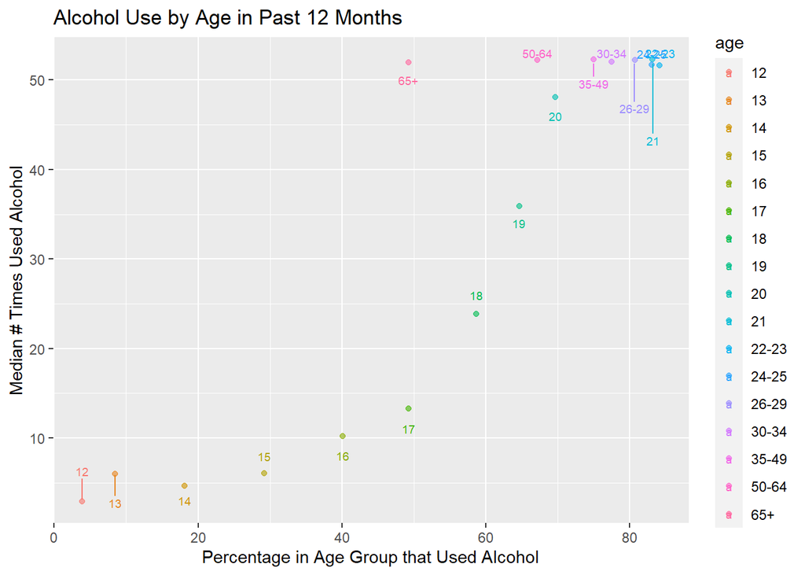

```r
ggplot(drugs_cleaner) +
  aes(x = alcohol.use,
      y = alcohol.frequency,
      fill = age,
      color = age) +
  geom_jitter(alpha = .6) +
  labs(
    title = "Alcohol Use by Age in Past 12 Months",
    x = "Percentage in Age Group that Used Alcohol",
    y = "Median # Times Used Alcohol") +
  geom_text_repel(aes(label = age),
                  box.padding = .5,
                  direction = "y",
                  size = 2.5,
                  max.overlaps = Inf)
```

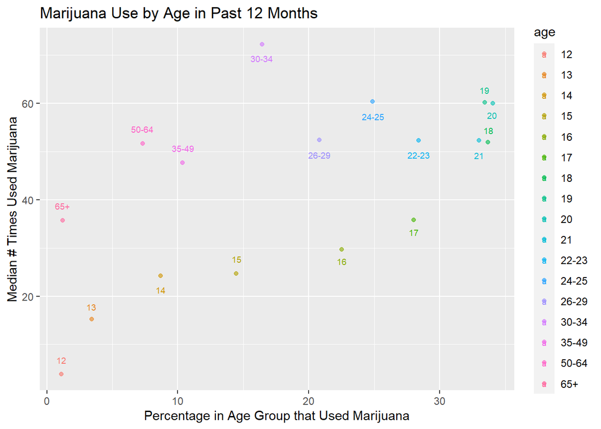

```r
ggplot(drugs_cleaner) +
  aes(x = marijuana.use,
      y = marijuana.frequency,
      fill = age,
      color = age) +
  geom_jitter(alpha = .6) +
  labs(
    title = "Marijuana Use by Age in Past 12 Months",
    x = "Percentage in Age Group that Used Marijuana",
    y = "Median # Times Used Marijuana") +
  geom_text_repel(aes(label = age),
                  box.padding = .5,
                  direction = "y",
                  size = 2.5,
                  max.overlaps = Inf)
```

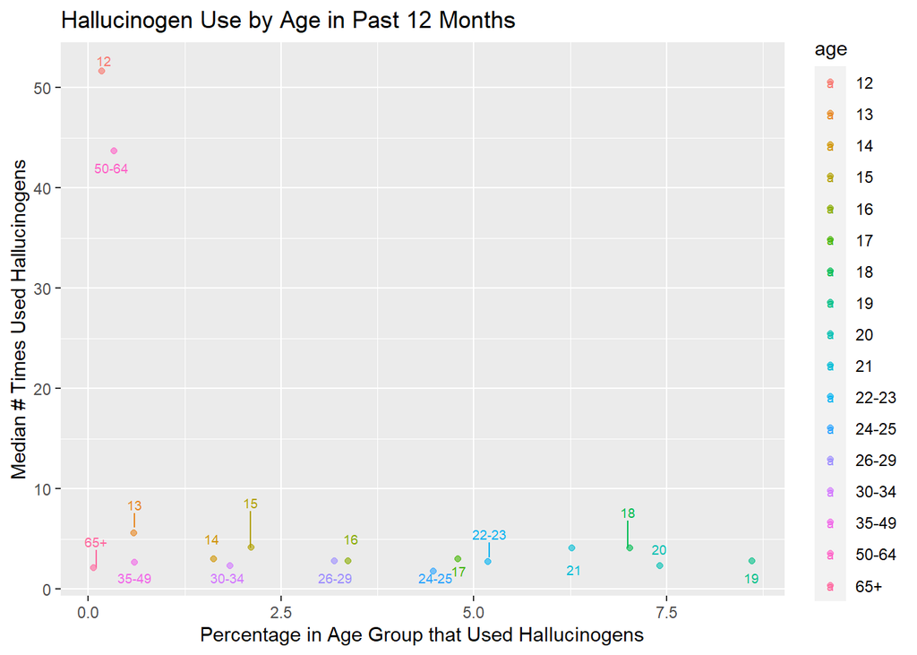

```r
ggplot(drugs_cleaner) +
  aes(x = hallucinogen.use,
      y = hallucinogen.frequency,
      fill = age,
      color = age) +
  geom_jitter(alpha = .6) +
  labs(
    title = "Hallucinogen Use by Age in Past 12 Months",
    x = "Percentage in Age Group that Used Hallucinogens",
    y = "Median # Times Used Hallucinogens") +
  geom_text_repel(aes(label = age),
                  box.padding = .5,
                  direction = "y",
                  size = 2.5,
                  max.overlaps = Inf)
```

# Step 8: Let’s perform the Chi-square test of independence to see if there are the relationships between drug use and age, and drug frequency and age, per my hypotheses:

```r
alc_use_chisq <- chisq.test(drugs_cleaner$alcohol.use, drugs_cleaner$age)
alc_use_chisq
```

```
##
##  Pearson's Chi-squared test
##
## data:  drugs_cleaner$alcohol.use and drugs_cleaner$age
## X-squared = 255, df = 240, p-value = 0.2416
```

```r
alc_freq_chisq <- chisq.test(drugs_cleaner$alcohol.frequency, drugs_cleaner$age)
alc_freq_chisq
```

```
##
##  Pearson's Chi-squared test
##
## data:  drugs_cleaner$alcohol.frequency and drugs_cleaner$age
## X-squared = 136, df = 128, p-value = 0.2976
```

```r
marij_use_chisq <- chisq.test(drugs_cleaner$marijuana.use, drugs_cleaner$age)
marij_use_chisq
```

```
##
##  Pearson's Chi-squared test
##
## data:  drugs_cleaner$marijuana.use and drugs_cleaner$age
## X-squared = 272, df = 256, p-value = 0.2351
```

```r
marij_freq_chisq <- chisq.test(drugs_cleaner$marijuana.frequency, drugs_cleaner$age)
marij_freq_chisq
```

```
##
##  Pearson's Chi-squared test
##
## data:  drugs_cleaner$marijuana.frequency and drugs_cleaner$age
## X-squared = 153, df = 144, p-value = 0.2882
```

```r
hallu_use_chisq <- chisq.test(drugs_cleaner$hallucinogen.use, drugs_cleaner$age)
hallu_use_chisq
```

```
##
##  Pearson's Chi-squared test
##
## data:  drugs_cleaner$hallucinogen.use and drugs_cleaner$age
## X-squared = 255, df = 240, p-value = 0.2416
```

```r
hallu_freq_chisq <- chisq.test(drugs_cleaner$hallucinogen.frequency, drugs_cleaner$age)
hallu_freq_chisq
```

```
##
##  Pearson's Chi-squared test
##
## data:  drugs_cleaner$hallucinogen.frequency and drugs_cleaner$age
## X-squared = 85, df = 80, p-value = 0.33
```

### Unfortunately, none of our chi-squares tests were signficant (*p* > .05). This may be due to the way the age groups were coded, or an error in the test I used.

# Step 9: To explore if the lack of significance was due to the coding of age groups, or if the relationship only exists among those 12-21 years old, let’s filter the data to that age range and re-run our tests.

```r
drugs_young <- subset(drugs_cleaner, age <= "21")
```

```r
alc_use_chisq_y <- chisq.test(drugs_young$alcohol.use, drugs_young$age)
alc_use_chisq_y
```

```
##
##  Pearson's Chi-squared test
##
## data:  drugs_young$alcohol.use and drugs_young$age
## X-squared = 90, df = 81, p-value = 0.2313
```

```r
alc_freq_chisq_y <- chisq.test(drugs_young$alcohol.frequency, drugs_young$age)
alc_freq_chisq_y
```

```
##
##  Pearson's Chi-squared test
##
## data:  drugs_young$alcohol.frequency and drugs_young$age
## X-squared = 80, df = 72, p-value = 0.2424
```

```r
marij_use_chisq_y <- chisq.test(drugs_young$marijuana.use, drugs_young$age)
marij_use_chisq_y
```

```
##
##  Pearson's Chi-squared test
##
## data:  drugs_young$marijuana.use and drugs_young$age
## X-squared = 90, df = 81, p-value = 0.2313
```

```r
marij_freq_chisq_y <- chisq.test(drugs_young$marijuana.frequency, drugs_young$age)
marij_freq_chisq_y
```

```
##
##  Pearson's Chi-squared test
##
## data:  drugs_young$marijuana.frequency and drugs_young$age
## X-squared = 70, df = 63, p-value = 0.2544
```

```r
hallu_use_chisq_y <- chisq.test(drugs_young$hallucinogen.use, drugs_young$age)
hallu_use_chisq_y
```

```
##
##  Pearson's Chi-squared test
##
## data:  drugs_young$hallucinogen.use and drugs_young$age
## X-squared = 90, df = 81, p-value = 0.2313
```

```r
hallu_freq_chisq_y <- chisq.test(drugs_young$hallucinogen.frequency, drugs_young$age)
hallu_freq_chisq_y
```

```
##
##  Pearson's Chi-squared test
##
## data:  drugs_young$hallucinogen.frequency and drugs_young$age
## X-squared = 40, df = 36, p-value = 0.297
```

### Unfortunately, none of these tests were signficant either (*p* > .05). If I used the correct test, this means that there is not a signficant correlation betwwen age and alcohol, marijuana, or hallucinogen use or frequency.

#### *Note for Dr. Wiernik: For this correlation test, I chose to use the Chi-square test because I wanted to compare age (categorical variable) to drug use or frequency (numeric variable). I tried running a one-way ANOVA as well, but those tests did not produce any p values, which makes me believe that that test would not work either. I have no idea what other analytical tests I could run, and this assignment is making me realize I need to take more statistics classes.*

# Step 10: Back to the drawing board. I’m curious if use (percentage of people who have used a substance in the past 12 months) and frequency (median number of times that substance was used in the past 12 months) are correlated, to provide insight into addiction or dependance on a substance.

### New hypotheses:

1. Alcohol use and frequency will be correlated.
2. Marijuana use and frequency will be correlated.
3. Hallucinogen use and frequency will NOT be correlated.

```r
cor.test(drugs_cleaner$alcohol.use,
         drugs_cleaner$alcohol.frequency,
         method = "pearson")
```

```
##
##  Pearson's product-moment correlation
##
## data:  drugs_cleaner$alcohol.use and drugs_cleaner$alcohol.frequency
## t = 7.8995, df = 15, p-value = 1.006e-06
## alternative hypothesis: true correlation is not equal to 0
## 95 percent confidence interval:
##  0.7340243 0.9629554
## sample estimates:
##       cor
## 0.8978893
```

```r
cor.test(drugs_cleaner$marijuana.use,
         drugs_cleaner$marijuana.frequency,
         method = "pearson")
```

```
##
##  Pearson's product-moment correlation
##
## data:  drugs_cleaner$marijuana.use and drugs_cleaner$marijuana.frequency
## t = 3.0255, df = 15, p-value = 0.008519
## alternative hypothesis: true correlation is not equal to 0
## 95 percent confidence interval:
##  0.1916823 0.8459477
## sample estimates:
##       cor
## 0.6156102
```

```r
cor.test(drugs_cleaner$hallucinogen.use,
         drugs_cleaner$hallucinogen.frequency,
         method = "pearson")
```

```
##
##  Pearson's product-moment correlation
##
## data:  drugs_cleaner$hallucinogen.use and drugs_cleaner$hallucinogen.frequency
## t = -1.8334, df = 15, p-value = 0.08666
## alternative hypothesis: true correlation is not equal to 0
## 95 percent confidence interval:
##  -0.75354163  0.06644692
## sample estimates:
##        cor
## -0.4278627
```

### Finally. We have significant results. Alcohol use and frequency are signficantly correlated (r = .90, p < .001), marijuana use and frequency are signficantly correlated (r = .62, p < .01), and hallucinogen use and frequency are NOT signficantly correlated, although it is trending towards a negative correlation (r = -.43, p = .08).

# **Interpretation of the Findings**

### Based on our analyses, there does not seem to be a significant difference in either alcohol, marijuana, or hallucinogen use or frequency by age. This suggests that these common drugs may be used in similar amounts across age groups (*although our plots don’t necessarily suggest this?*). However, there is a signficant correlation between the percentage of the population that use alcohol or marijuana within the last 12 months and the median number of times that these substances are used. To me, this suggests that people are not just trying these substances once; instead, they are using them frequently. On the other hand, hallucinogen use and frequency was not signficant, although it was trending towards a negative correlation. This means that although people may try hallucinogens, they don’t use them too often.